# 重賞レース予測レポート【毎時自動更新中】

作成日時: 2026/07/26 10:04:43

☞ [マニュアル(pdf)](https://ryutoro-galois.github.io/keiba-predictor/manual/manual.pdf)

☞ 過去6年の同一レース結果: [2025年](https://ryutoro-galois.github.io/keiba-predictor/report/PredResult_2025y_raceDate_20250727_20250727.html), [2024年](https://ryutoro-galois.github.io/keiba-predictor/report/PredResult_2024y_raceDate_20240727_20240728.html), [2023年](https://ryutoro-galois.github.io/keiba-predictor/report/PredResult_2023y_raceDate_20230723_20230723.html), [2022年](https://ryutoro-galois.github.io/keiba-predictor/report/PredResult_2022y_raceDate_20220724_20220724.html), [2021年](https://ryutoro-galois.github.io/keiba-predictor/report/PredResult_2021y_raceDate_20210725_20210725.html), [2020年](https://ryutoro-galois.github.io/keiba-predictor/report/PredResult_2020y_raceDate_20200726_20200726.html)

☞ 過去4週間の別レース結果: [1週前(7/19)](https://ryutoro-galois.github.io/keiba-predictor/report/PredResult_2026y_raceDate_20260719_20260719.html), [2週前(7/12)](https://ryutoro-galois.github.io/keiba-predictor/report/PredResult_2026y_raceDate_20260712_20260712.html), [3週前(7/5)](https://ryutoro-galois.github.io/keiba-predictor/report/PredResult_2026y_raceDate_20260705_20260705.html), [4週前(6/28)](https://ryutoro-galois.github.io/keiba-predictor/report/PredResult_2026y_raceDate_20260628_20260628.html)

☞ netkeiba: [関屋記念(GⅢ)](https://race.netkeiba.com/race/shutuba.html?race_id=202604020207&rf=race_list), [東海ステークス(GⅢ)](https://race.netkeiba.com/race/shutuba.html?race_id=202607020207&rf=race_list)

## 0. 推し馬予測 (AI予測)

### 【関屋記念(GⅢ) 2026/07/26(日)】

- 本命(◎): 1-3着内確率(勝負強さ)が1位の馬
- 対抗(◯): 1-3着内確率が2-N位(20%程度以上)の中で予測タイムが最も速い馬
- 3番手(▲): 1-3着内確率が2-N位(20%程度以上)のでダークホース確率が最も高い馬
- 穴: ダークホース確率が上位1-M位(40%程度以上)の中で1-3着内確率が最も高い馬

| 推し馬 | 枠番 | 馬番 | 人気 | オッズ | 馬名 | 騎手 | 調教師 | 予測タイム(sec) | 1_順位 | 1-3着内確率(%) | 2_順位 | ﾀﾞｰｸﾎｰｽ確率(%) | 3_順位 |
| --- | --- | --- | --- | --- | --- | --- | --- | --- | --- | --- | --- | --- | --- |
| 本命(◎) | 3 | 3 | 2 | 5.0 | アンパドゥ | 岩田望来 | 木村哲也 | 102.2 | 13.0 | 31.2 | 1 | 0.3 | 14 |
| 対抗(◯) | 1 | 1 | 3 | 7.5 | ファーヴェント | 西塚洸二 | 藤原英昭 | 91.5 | 1.5 | 25.4 | 2 | 1.3 | 9 |
| 3番手(▲) | 6 | 10 | 6 | 10.4 | クランフォード | 菊沢一樹 | 杉山晴紀 | 99.7 | 9.0 | 24.9 | 3 | 1.1 | 10 |
| 穴 | 2 | 2 | 13 | 35.8 | ジュタ | 吉田豊 | 矢作芳人 | 92.0 | 4.0 | 9.0 | 8 | 47.2 | 1 |

- 本命(◎): 1-3着内確率(勝負強さ)が1位の馬
- 対抗(◯): 1-3着内確率が2-N位(20%程度以上)の中で予測タイムが最も速い馬
- 3番手(▲): 1-3着内確率が2-N位(20%程度以上)のでダークホース確率が最も高い馬
- 穴: ダークホース確率が上位1-M位(40%程度以上)の中で1-3着内確率が最も高い馬

| 推し馬 | 枠番 | 馬番 | 人気 | オッズ | 馬名 | 騎手 | 調教師 | 予測タイム(sec) | 1_順位 | 1-3着内確率(%) | 2_順位 | ﾀﾞｰｸﾎｰｽ確率(%) | 3_順位 |
| --- | --- | --- | --- | --- | --- | --- | --- | --- | --- | --- | --- | --- | --- |
| 本命(◎) | 5 | 7 | 2 | 4.5 | ダノンフィーゴ | 川田将雅 | 友道康夫 | 120.1 | 10 | 31.1 | 1 | 0.5 | 14 |
| 対抗(◯) | 6 | 9 | 5 | 8.5 | インユアパレス | 横山武史 | 須貝尚介 | 111.3 | 5 | 22.8 | 4 | 1.0 | 11 |
| 3番手(▲) | 5 | 8 | 4 | 8.3 | ベルジュロネット | Ｍ．デムーロ | 大久保龍志 | 121.8 | 14 | 25.8 | 2 | 1.1 | 9 |
| 穴 | 3 | 4 | 13 | 143.0 | モンドプリューム | 武藤雅 | 水野貴広 | 120.8 | 13 | 4.1 | 11 | 42.2 | 1 |

## 1. 予測チャート (タイム/勝負強さ)

### 【関屋記念(GⅢ)】

2026/07/26(日), 04_新潟, 芝左外1600m

[interactive chart not shown]

[interactive chart not shown]

## 2. オッズモニタリング (毎時)

### 【関屋記念】

[interactive chart not shown]

### 【東海ステークス】

[interactive chart not shown]

## 3. 出馬表

### 【関屋記念 2026/07/26(日) 】

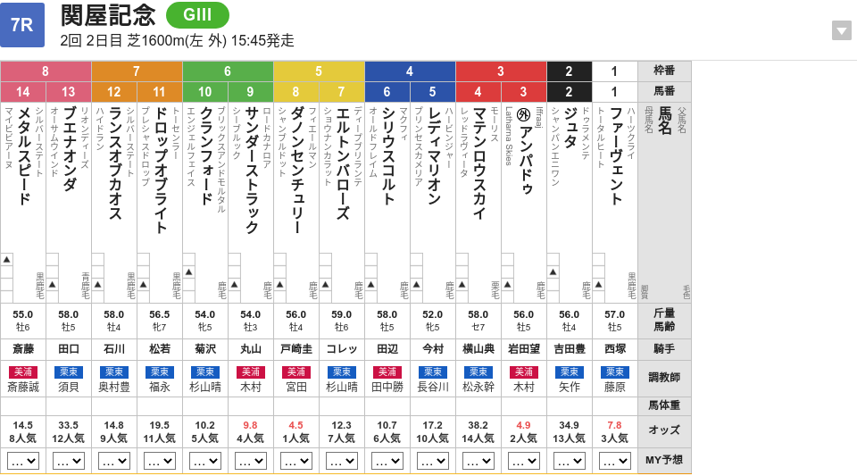

### 【東海ステークス 2026/07/26(日) 】

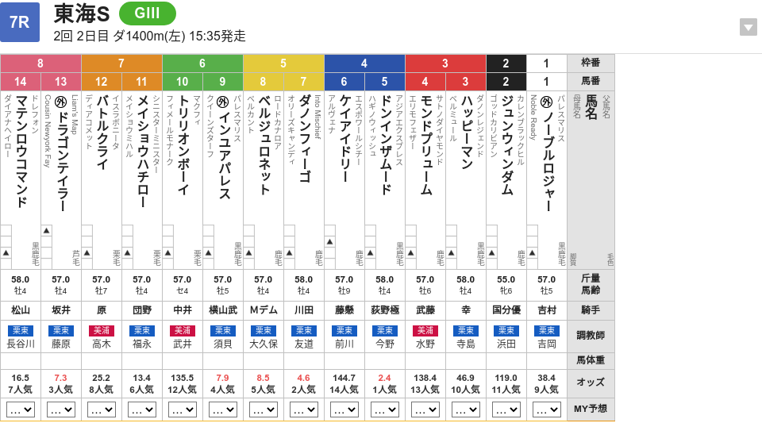

## 4. 単勝予測結果

### 【関屋記念(GⅢ) 2026/07/26(日)】

| 枠番 | 馬番 | 人気 | オッズ | 馬名 | 騎手 | 調教師 | 予測タイム(sec) | 1_順位 | 1-3着内確率(%) | 2_順位 | ﾀﾞｰｸﾎｰｽ確率(%) | 3_順位 |
| --- | --- | --- | --- | --- | --- | --- | --- | --- | --- | --- | --- | --- |
| 1 | 1 | 3 | 7.5 | ファーヴェント | 西塚洸二 | 藤原英昭 | 91.5 | 1.5 | 25.4 | 2 | 1.3 | 9 |
| 2 | 2 | 13 | 35.8 | ジュタ | 吉田豊 | 矢作芳人 | 92.0 | 4.0 | 9.0 | 8 | 47.2 | 1 |
| 3 | 3 | 2 | 5.0 | アンパドゥ | 岩田望来 | 木村哲也 | 102.2 | 13.0 | 31.2 | 1 | 0.3 | 14 |
| 3 | 4 | 14 | 39.5 | マテンロウスカイ | 横山典弘 | 松永幹夫 | 99.5 | 8.0 | 2.9 | 13 | 10.2 | 6 |
| 4 | 5 | 10 | 17.3 | レディマリオン | 今村聖奈 | 長谷川浩大 | 94.2 | 6.0 | 4.8 | 11 | 35.5 | 3 |
| 4 | 6 | 5 | 10.3 | シリウスコルト | 田辺裕信 | 田中勝春 | 92.2 | 5.0 | 14.2 | 5 | 1.5 | 8 |
| 5 | 7 | 7 | 12.1 | エルトンバローズ | Ｊ．コレット | 杉山晴紀 | 98.4 | 7.0 | 9.3 | 6 | 0.8 | 11 |
| 5 | 8 | 1 | 4.6 | ダノンセンチュリー | 戸崎圭太 | 宮田敬介 | 91.5 | 1.5 | 17.3 | 4 | 0.4 | 13 |
| 6 | 9 | 4 | 9.8 | サンダーストラック | 丸山元気 | 木村哲也 | 100.5 | 11.0 | 7.0 | 9 | 0.7 | 12 |
| 6 | 10 | 6 | 10.4 | クランフォード | 菊沢一樹 | 杉山晴紀 | 99.7 | 9.0 | 24.9 | 3 | 1.1 | 10 |

[output cut: 4 more lines]

| 枠番 | 馬番 | 人気 | オッズ | 馬名 | 騎手 | 調教師 | 予測タイム(sec) | 1_順位 | 1-3着内確率(%) | 2_順位 | ﾀﾞｰｸﾎｰｽ確率(%) | 3_順位 |
| --- | --- | --- | --- | --- | --- | --- | --- | --- | --- | --- | --- | --- |
| 1 | 1 | 9 | 39.6 | ノーブルロジャー | 吉村誠之助 | 吉岡辰弥 | 111.1 | 4 | 11.6 | 7 | 32.9 | 2 |
| 2 | 2 | 11 | 122.7 | ジュンウィンダム | 国分優作 | 浜田多実雄 | 119.2 | 6 | 2.5 | 12 | 11.5 | 7 |
| 3 | 3 | 10 | 46.9 | ハッピーマン | 幸英明 | 寺島良 | 119.9 | 9 | 4.8 | 10 | 15.7 | 5 |
| 3 | 4 | 13 | 143.0 | モンドプリューム | 武藤雅 | 水野貴広 | 120.8 | 13 | 4.1 | 11 | 42.2 | 1 |
| 4 | 5 | 1 | 2.4 | ドンインザムード | 荻野極 | 今野貞一 | 109.8 | 1 | 14.6 | 5 | 0.6 | 13 |
| 4 | 6 | 14 | 146.2 | ケイアイドリー | 藤懸貴志 | 前川恭子 | 119.6 | 7 | 4.8 | 9 | 16.9 | 4 |
| 5 | 7 | 2 | 4.5 | ダノンフィーゴ | 川田将雅 | 友道康夫 | 120.1 | 10 | 31.1 | 1 | 0.5 | 14 |
| 5 | 8 | 4 | 8.3 | ベルジュロネット | Ｍ．デムーロ | 大久保龍志 | 121.8 | 14 | 25.8 | 2 | 1.1 | 9 |
| 6 | 9 | 5 | 8.5 | インユアパレス | 横山武史 | 須貝尚介 | 111.3 | 5 | 22.8 | 4 | 1.0 | 11 |
| 6 | 10 | 12 | 132.7 | トリリオンボーイ | 中井裕二 | 武井亮 | 119.8 | 8 | 2.3 | 13 | 14.0 | 6 |

[output cut: 4 more lines]

## 5. 人気と着順の乖離率推移

### 【関屋記念_1990y_2019y】

[interactive chart not shown]

### 【東海ステークス_1997y_2019y】

[interactive chart not shown]

### 【関屋記念_1990y_2019y】

| No | 開催年 | 不整合率(%) | 頭数 | 人気別着順(1-3位) | 人気別着順(全体) |
| --- | --- | --- | --- | --- | --- |
| 30 | 2019 | 43.1 | 17頭 | 1-6-4 | 1\|6\|4\|8\|5\|11\|13\|9\|3\|7\|12\|10\|15\|2\|14\|16\|17 |
| 29 | 2018 | 29.1 | 15頭 | 1-5-3 | 1\|5\|3\|11\|8\|2\|9\|10\|12\|4\|6\|7\|13\|15\|14 |
| 28 | 2017 | 54.5 | 16頭 | 7-4-5 | 7\|4\|5\|6\|8\|2\|14\|15\|16\|11\|13\|1\|10\|9\|3\|12 |
| 27 | 2016 | 37.9 | 18頭 | 3-7-1 | 3\|7\|1\|14\|2\|6\|13\|8\|5\|17\|4\|9\|16\|15\|10\|11\|12\|18 |
| 26 | 2015 | 36.8 | 12頭 | 2-6-9 | 2\|6\|9\|8\|7\|10\|1\|3\|5\|11\|4\|12 |
| 25 | 2014 | 44.4 | 16頭 | 4-1-6 | 4\|1\|6\|8\|10\|12\|11\|13\|3\|5\|14\|2\|9\|15\|7\|16 |
| 24 | 2013 | 33.5 | 17頭 | 4-1-3 | 4\|1\|3\|2\|9\|15\|6\|13\|12\|5\|7\|16\|10\|17\|11\|14\|18 |
| 23 | 2012 | 43.9 | 18頭 | 1-5-8 | 1\|5\|8\|4\|6\|7\|12\|18\|10\|13\|14\|3\|17\|11\|16\|9\|15\|2 |
| 22 | 2011 | 49.0 | 12頭 | 4-2-3 | 4\|2\|3\|7\|1\|5\|11\|10\|9\|6\|8\|12 |
| 21 | 2010 | 40.0 | 18頭 | 6-2-10 | 6\|2\|10\|13\|5\|1\|7\|4\|3\|14\|16\|9\|8\|11\|15\|12\|17\|18 |

[output cut: 20 more lines]

### 【東海ステークス_1997y_2019y】

| No | 開催年 | 不整合率(%) | 頭数 | 人気別着順(1-3位) | 人気別着順(全体) |
| --- | --- | --- | --- | --- | --- |
| 21 | 2019 | 19.5 | 13頭 | 1-2-4 | 1\|2\|4\|6\|8\|7\|10\|5\|12\|13\|9\|3\|11 |
| 20 | 2018 | 36.7 | 16頭 | 1-13-6 | 1\|13\|6\|14\|5\|10\|4\|9\|2\|15\|8\|7\|3\|16\|11\|12 |
| 19 | 2017 | 32.3 | 16頭 | 1-12-10 | 1\|12\|10\|13\|11\|3\|8\|2\|7\|15\|6\|4\|14\|5\|16\|9 |
| 18 | 2016 | 40.7 | 12頭 | 4-2-1 | 4\|2\|1\|11\|10\|5\|6\|7\|8\|9\|3\|12 |
| 17 | 2015 | 36.7 | 14頭 | 1-9-3 | 1\|9\|3\|10\|7\|13\|6\|4\|11\|12\|2\|8\|5\|14 |
| 16 | 2014 | 26.4 | 16頭 | 1-3-8 | 1\|3\|8\|9\|4\|12\|10\|2\|5\|6\|7\|11\|14\|15\|13\|16 |
| 15 | 2013 | 30.7 | 16頭 | 4-8-1 | 4\|8\|1\|7\|2\|6\|3\|9\|15\|11\|16\|10\|5\|12\|13\|14 |
| 14 | 2012 | 65.9 | 15頭 | 4-3-11 | 4\|3\|11\|6\|2\|12\|13\|8\|9\|1\|10\|14\|15\|7\|5 |
| 13 | 2011 | 42.5 | 14頭 | 2-6-5 | 2\|6\|5\|4\|1\|3\|12\|8\|13\|11\|10\|7\|9\|14 |
| 12 | 2010 | 40.6 | 15頭 | 3-1-10 | 3\|1\|10\|5\|8\|9\|12\|2\|6\|11\|4\|14\|7\|13\|15 |

[output cut: 11 more lines]

## 6. 1-3番人気馬の着順分類予測

### 【関屋記念】

| 分類 | 凡例 | 発生確率(%) | 当該レース | 当該レースランク | 直近1年間 |
| --- | --- | --- | --- | --- | --- |
| 4: 1,2番人気のみ (4_pop12) | 1 \| 2 \| * | 18.3 | 1.32 | 1.32 | 0.37 |
| 1: 1番人気のみ (1_pop1) | 1 \| * \| * | 18.2 | 0.50 | 0.50 | 0.36 |
| 8: 1,2,3番人気すべて着外 (8_darkhorse) | * \| * \| * | 14.2 | 1.71 | 1.71 | 0.00 |
| 5: 1,3番人気のみ (5_pop13) | 1 \| 3 \| * | 13.6 | 0.61 | 0.61 | 0.00 |
| 6: 2,3番人気のみ (6_pop23) | 2 \| 3 \| * | 10.0 | 1.20 | 1.20 | 0.00 |
| 2: 2番人気のみ (2_pop2) | 2 \| * \| * | 9.7 | 1.17 | 1.17 | 0.00 |
| 3: 3番人気のみ (3_pop3) | 3 \| * \| * | 8.6 | 3.07 | 3.07 | 0.00 |
| 7: 1,2,3番人気すべて着内 (7_pop123) | 1 \| 2 \| 3 | 7.2 | 0.00 | 0.00 | 0.00 |

### 【東海ステークス】

| 分類 | 凡例 | 発生確率(%) | 当該レース | 当該レースランク | 直近1年間 |
| --- | --- | --- | --- | --- | --- |
| 4: 1,2番人気のみ (4_pop12) | 1 \| 2 \| * | 20.0 | 0.68 | 0.68 | 0.40 |
| 1: 1番人気のみ (1_pop1) | 1 \| * \| * | 17.9 | 0.97 | 0.97 | 0.36 |
| 5: 1,3番人気のみ (5_pop13) | 1 \| 3 \| * | 13.9 | 0.94 | 0.94 | 0.00 |
| 8: 1,2,3番人気すべて着外 (8_darkhorse) | * \| * \| * | 13.3 | 1.80 | 1.80 | 0.00 |
| 2: 2番人気のみ (2_pop2) | 2 \| * \| * | 9.9 | 0.89 | 0.89 | 0.00 |
| 6: 2,3番人気のみ (6_pop23) | 2 \| 3 \| * | 9.0 | 2.43 | 2.43 | 0.00 |
| 3: 3番人気のみ (3_pop3) | 3 \| * \| * | 8.4 | 1.14 | 1.14 | 0.00 |
| 7: 1,2,3番人気すべて着内 (7_pop123) | 1 \| 2 \| 3 | 7.6 | 1.03 | 1.03 | 0.00 |

## 7. 3連複予測結果

### 【関屋記念(GⅢ) 2026/07/26(日)】

| 分類 | 馬番 | 枠番 | 人気 | 平均予測タイム(sec) | 1-3着内確率(%) | ﾀﾞｰｸﾎｰｽ確率(%) | 馬名 | 騎手 | 調教師 |
| --- | --- | --- | --- | --- | --- | --- | --- | --- | --- |
| 6: 2,3番人気のみ (6_pop23) | 3-1-10 | 3-1-6 | 2-3-6 | 97.80 | 1.98 | 0.00 | アンパドゥ \| ファーヴェント \| クランフォード | 岩田望来 \| 西塚洸二 \| 菊沢一樹 | 木村哲也 \| 藤原英昭 \| 杉山晴紀 |
| 7: 1,2,3番人気すべて着内 (7_pop123) | 8-3-1 | 5-3-1 | 1-2-3 | 95.07 | 1.37 | 0.00 | ダノンセンチュリー \| アンパドゥ \| ファーヴェント | 戸崎圭太 \| 岩田望来 \| 西塚洸二 | 宮田敬介 \| 木村哲也 \| 藤原英昭 |
| 4: 1,2番人気のみ (4_pop12) | 8-3-10 | 5-3-6 | 1-2-6 | 97.80 | 1.35 | 0.00 | ダノンセンチュリー \| アンパドゥ \| クランフォード | 戸崎圭太 \| 岩田望来 \| 菊沢一樹 | 宮田敬介 \| 木村哲也 \| 杉山晴紀 |
| 6: 2,3番人気のみ (6_pop23) | 3-1-6 | 3-1-4 | 2-3-5 | 95.30 | 1.12 | 0.00 | アンパドゥ \| ファーヴェント \| シリウスコルト | 岩田望来 \| 西塚洸二 \| 田辺裕信 | 木村哲也 \| 藤原英昭 \| 田中勝春 |
| 2: 2番人気のみ (2_pop2) | 3-6-10 | 3-4-6 | 2-5-6 | 98.03 | 1.11 | 0.00 | アンパドゥ \| シリウスコルト \| クランフォード | 岩田望来 \| 田辺裕信 \| 菊沢一樹 | 木村哲也 \| 田中勝春 \| 杉山晴紀 |
| 5: 1,3番人気のみ (5_pop13) | 8-1-10 | 5-1-6 | 1-3-6 | 94.23 | 1.09 | 0.00 | ダノンセンチュリー \| ファーヴェント \| クランフォード | 戸崎圭太 \| 西塚洸二 \| 菊沢一樹 | 宮田敬介 \| 藤原英昭 \| 杉山晴紀 |
| 3: 3番人気のみ (3_pop3) | 1-6-10 | 1-4-6 | 3-5-6 | 94.47 | 0.90 | 0.00 | ファーヴェント \| シリウスコルト \| クランフォード | 西塚洸二 \| 田辺裕信 \| 菊沢一樹 | 藤原英昭 \| 田中勝春 \| 杉山晴紀 |
| 4: 1,2番人気のみ (4_pop12) | 8-3-6 | 5-3-4 | 1-2-5 | 95.30 | 0.77 | 0.00 | ダノンセンチュリー \| アンパドゥ \| シリウスコルト | 戸崎圭太 \| 岩田望来 \| 田辺裕信 | 宮田敬介 \| 木村哲也 \| 田中勝春 |
| 6: 2,3番人気のみ (6_pop23) | 3-1-7 | 3-1-5 | 2-3-7 | 97.37 | 0.73 | 0.00 | アンパドゥ \| ファーヴェント \| エルトンバローズ | 岩田望来 \| 西塚洸二 \| Ｊ．コレット | 木村哲也 \| 藤原英昭 \| 杉山晴紀 |
| 2: 2番人気のみ (2_pop2) | 3-10-7 | 3-6-5 | 2-6-7 | 100.10 | 0.72 | 0.00 | アンパドゥ \| クランフォード \| エルトンバローズ | 岩田望来 \| 菊沢一樹 \| Ｊ．コレット | 木村哲也 \| 杉山晴紀 \| 杉山晴紀 |

[output cut: 354 more lines]

| 分類 | 馬番 | 枠番 | 人気 | 平均予測タイム(sec) | 1-3着内確率(%) | ﾀﾞｰｸﾎｰｽ確率(%) | 馬名 | 騎手 | 調教師 |
| --- | --- | --- | --- | --- | --- | --- | --- | --- | --- |
| 6: 2,3番人気のみ (6_pop23) | 7-13-8 | 5-8-5 | 2-3-4 | 120.73 | 1.93 | 0.00 | ダノンフィーゴ \| ドラゴンテイラー \| ベルジュロネット | 川田将雅 \| 坂井瑠星 \| Ｍ．デムーロ | 友道康夫 \| 藤原英昭 \| 大久保龍志 |
| 2: 2番人気のみ (2_pop2) | 7-8-9 | 5-5-6 | 2-4-5 | 117.73 | 1.83 | 0.00 | ダノンフィーゴ \| ベルジュロネット \| インユアパレス | 川田将雅 \| Ｍ．デムーロ \| 横山武史 | 友道康夫 \| 大久保龍志 \| 須貝尚介 |
| 6: 2,3番人気のみ (6_pop23) | 7-13-9 | 5-8-6 | 2-3-5 | 117.23 | 1.70 | 0.00 | ダノンフィーゴ \| ドラゴンテイラー \| インユアパレス | 川田将雅 \| 坂井瑠星 \| 横山武史 | 友道康夫 \| 藤原英昭 \| 須貝尚介 |
| 3: 3番人気のみ (3_pop3) | 13-8-9 | 8-5-6 | 3-4-5 | 117.80 | 1.41 | 0.00 | ドラゴンテイラー \| ベルジュロネット \| インユアパレス | 坂井瑠星 \| Ｍ．デムーロ \| 横山武史 | 藤原英昭 \| 大久保龍志 \| 須貝尚介 |
| 4: 1,2番人気のみ (4_pop12) | 5-7-8 | 4-5-5 | 1-2-4 | 117.23 | 1.17 | 0.00 | ドンインザムード \| ダノンフィーゴ \| ベルジュロネット | 荻野極 \| 川田将雅 \| Ｍ．デムーロ | 今野貞一 \| 友道康夫 \| 大久保龍志 |
| 2: 2番人気のみ (2_pop2) | 7-8-11 | 5-5-7 | 2-4-6 | 117.43 | 1.11 | 0.00 | ダノンフィーゴ \| ベルジュロネット \| メイショウハチロー | 川田将雅 \| Ｍ．デムーロ \| 団野大成 | 友道康夫 \| 大久保龍志 \| 福永祐一 |
| 7: 1,2,3番人気すべて着内 (7_pop123) | 5-7-13 | 4-5-8 | 1-2-3 | 116.73 | 1.09 | 0.00 | ドンインザムード \| ダノンフィーゴ \| ドラゴンテイラー | 荻野極 \| 川田将雅 \| 坂井瑠星 | 今野貞一 \| 友道康夫 \| 藤原英昭 |
| 4: 1,2番人気のみ (4_pop12) | 5-7-9 | 4-5-6 | 1-2-5 | 113.73 | 1.03 | 0.00 | ドンインザムード \| ダノンフィーゴ \| インユアパレス | 荻野極 \| 川田将雅 \| 横山武史 | 今野貞一 \| 友道康夫 \| 須貝尚介 |
| 6: 2,3番人気のみ (6_pop23) | 7-13-11 | 5-8-7 | 2-3-6 | 116.93 | 1.03 | 0.00 | ダノンフィーゴ \| ドラゴンテイラー \| メイショウハチロー | 川田将雅 \| 坂井瑠星 \| 団野大成 | 友道康夫 \| 藤原英昭 \| 福永祐一 |
| 2: 2番人気のみ (2_pop2) | 7-9-11 | 5-6-7 | 2-5-6 | 113.93 | 0.98 | 0.00 | ダノンフィーゴ \| インユアパレス \| メイショウハチロー | 川田将雅 \| 横山武史 \| 団野大成 | 友道康夫 \| 須貝尚介 \| 福永祐一 |

[output cut: 354 more lines]

## 8. 直近の全レース情報

| No | 日付 | 競馬場 | R | 発走 | レース名 | 距離 | 頭数 | URL(netkeiba) |
| --- | --- | --- | --- | --- | --- | --- | --- | --- |
| 10 | 2026/07/26(日) | 04_新潟 | 6R | 15:10 | 出雲崎特別 | 1200 | 14頭 | https://race.netkeiba.com/race/shutuba.html?race_id=202604020206&amp;rf=race_list |
| 11 | 2026/07/26(日) | 04_新潟 | 7R | 15:45 | 関屋記念 | 1600 | 14頭 | https://race.netkeiba.com/race/shutuba.html?race_id=202604020207&amp;rf=race_list |
| 12 | 2026/07/26(日) | 04_新潟 | 8R | 16:20 | 麒麟山特別 | 1800 | 18頭 | https://race.netkeiba.com/race/shutuba.html?race_id=202604020208&amp;rf=race_list |
| 13 | 2026/07/26(日) | 07_中京 | 6R | 15:00 | 木曽川特別 | 2000 | 12頭 | https://race.netkeiba.com/race/shutuba.html?race_id=202607020206&amp;rf=race_list |
| 14 | 2026/07/26(日) | 07_中京 | 7R | 15:35 | 東海ステークス | 1400 | 14頭 | https://race.netkeiba.com/race/shutuba.html?race_id=202607020207&amp;rf=race_list |
| 15 | 2026/07/26(日) | 07_中京 | 8R | 16:10 | 遠州灘特別 | 1800 | 15頭 | https://race.netkeiba.com/race/shutuba.html?race_id=202607020208&amp;rf=race_list |
| 16 | 2026/07/26(日) | 01_札幌 | 10R | 14:50 | 羊ヶ丘特別 | 1500 | 12頭 | https://race.netkeiba.com/race/shutuba.html?race_id=202601010210&amp;rf=race_list |
| 17 | 2026/07/26(日) | 01_札幌 | 11R | 15:25 | 札幌日経賞 | 2600 | 13頭 | https://race.netkeiba.com/race/shutuba.html?race_id=202601010211&amp;rf=race_list |
| 18 | 2026/07/26(日) | 01_札幌 | 12R | 16:00 | 厚岸特別 | 2000 | 13頭 | https://race.netkeiba.com/race/shutuba.html?race_id=202601010212&amp;rf=race_list |